# Introduction to ncaahoopR

Jim Albert

1/23/2020

#### Introduction

ncaahoopR is a R package for scraping and graphing play-by-play men college basketball data

#### Load packages

We begin by loading the tidyverse and ncaahoopR packages.

```r
library(tidyverse)
library(ncaahoopR)
```

#### Scrape data for one game

To begin, let’s scrape the data for the exciting BGSU-Ohio contest of January 11, 2020.

I find the description of the game on ESPN:

https://www.espn.com/mens-college-basketball/game?gameId=401172643

Looking at the html address, I see the game id is 401172643

I can scrape this game by the `get_pbp_game()` function.

```r
d <- get_pbp_game(401172643)
```

Here are a few rows of this data frame.

```r
head(d, 2)
```

```
##     game_id       date home          away play_id half time_remaining_half
## 1 401172643 2020-01-11 Ohio Bowling Green       1    1               20:00
## 2 401172643 2020-01-11 Ohio Bowling Green       2    1               19:36
##   secs_remaining secs_remaining_absolute                  description
## 1           2400                    2400                         PLAY
## 2           2376                    2376 Tayler Mattos missed Jumper.
##   home_score away_score score_diff play_length  win_prob naive_win_prob
## 1          0          0          0           0 0.4401270            0.5
## 2          0          0          0          24 0.4402702            0.5
##   home_time_out_remaining away_time_out_remaining home_favored_by shot_x shot_y
## 1                       4                       4            -1.5     NA     NA
## 2                       4                       4            -1.5     NA     NA
##       shot_team shot_outcome       shooter assist three_pt free_throw
## 1          <NA>         <NA>          <NA>   <NA>       NA         NA
## 2 Bowling Green       missed Tayler Mattos   <NA>    FALSE      FALSE
##   possession_before possession_after
## 1              <NA>    Bowling Green
## 2     Bowling Green             Ohio
```

#### Game flow chart

The `game_flow()` function scrapes data for a game and plots the scores of both teams as a function of the minutes elapsed.

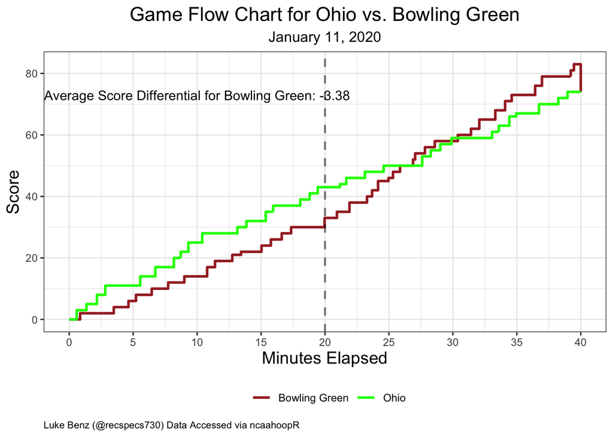

```r
game_flow(401172643, "green", "brown")
```

#### Win probability chart

The `gg_wp_chart()` scrapes the data and shows the win probabilities for each team as a function of the minutes elapsed.

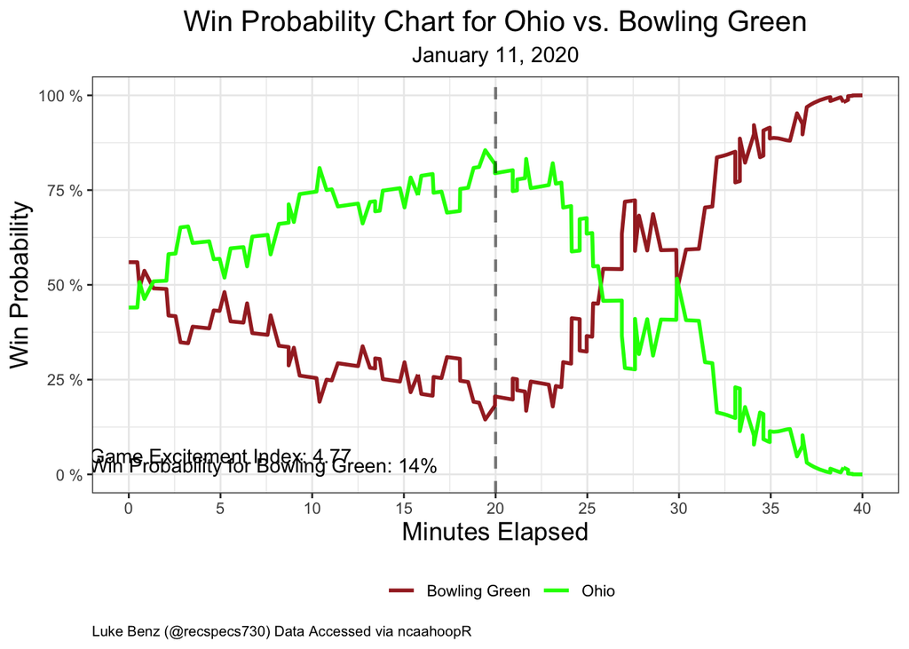

```r
gg_wp_chart(401172643, "green", "brown")
```

#### Shot charts

For many of the top league games (unfortunately not MAC games) shot location data is available. The `game_shot_chart()` graphs the shots for both teams. Here is an illustration (this is the Duke-Kentucky game of November 6, 2018).

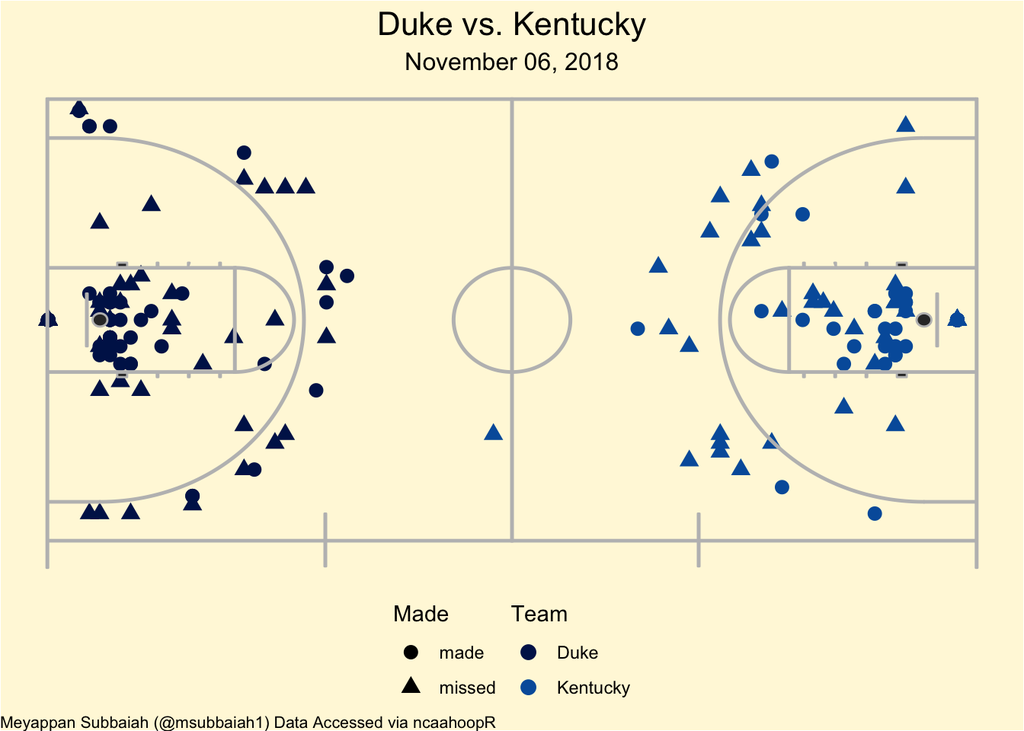

```r
game_shot_chart(game_id = 401082669)
```